# Lab 11: Classification

## Goals

Learning objectives:

- Basic EDA in Pandas
- Fit a classification model in Scikit-Learn (sklearn)

## Getting Started

Make teams, [claim your repo](https://github.com/Calvin-DS202-FA20/), clone, knit, etc. as usual. (see Lab 10 for reference.)

## Python

Please try to use Python (Pandas, sklearn) for this lab. For details about getting Python set up and tricks for how to use it, see Homework 4.

**Note**: This instructions document includes many of the results needed to answer the short answer questions. Include in your report both your answer to the question and also the code you use to reproduce what you need to answer it.

## Acquiring Data

```r
data_filename <- "data/autism.csv"
if (!file.exists(data_filename)) {
  dir.create("data")
  download.file("https://doi.org/10.1371/journal.pcbi.1005385.s001", data_filename)
}
```

```r
col_names <- names(read_csv(data_filename, n_max = 1, col_types = cols(.default = col_character())))
autism <- read_csv(data_filename, skip = 2, col_names = col_names, col_types = cols(
  .default = col_double(),
  Group = col_character()
))
```

```python
autism = r.autism
```

```python
import numpy as np
import pandas as pd
from sklearn.linear_model import LogisticRegression
from sklearn.model_selection import train_test_split, cross_validate
from sklearn.compose import make_column_transformer
from sklearn.pipeline import make_pipeline
from sklearn.preprocessing import StandardScaler
from sklearn.metrics import accuracy_score, precision_score, recall_score
```

## EDA

1. How many children are represented in this dataset? How many variables are there?
2. What two variables are unlike the others? What is different about them?

```
## <class 'pandas.core.frame.DataFrame'>
## RangeIndex: 206 entries, 0 to 205
## Data columns (total 26 columns):
##  #   Column              Non-Null Count  Dtype
## ---  ------              --------------  -----
##  0   Group               206 non-null    object
##  1   Methion.            206 non-null    float64
##  2   SAM                 206 non-null    float64
##  3   SAH                 206 non-null    float64
##  4   SAM/SAH             206 non-null    float64
##  5   % DNA methylation   206 non-null    float64
##  6   8-OHG               206 non-null    float64
##  7   Adenosine           206 non-null    float64
##  8   Homocysteine        206 non-null    float64
##  9   Cysteine            206 non-null    float64
```

[output cut: 18 more lines]

3. How many children do we have in each `Group`?

```
## ASD    83
## NEU    76
## SIB    47
## Name: Group, dtype: int64
```

## Classfication

4. Create a new `DataFrame` called `asd_vs_neu` that has no `SIB` children.
5. Verify that the new `DataFrame` has no `SIB` children but the same number of children in the other groups.

```
## ASD    83
## NEU    76
## Name: Group, dtype: int64
```

`sklearn` has some conventions for what variables are named:

- `X` designates the input data, one row per observation, one column per feature. It is uppercase because it’s a matrix.
- `y` designates the prediction targets, as a one-dimensional *vector* (and thus lowercase).
6. Create a variable called `y` (designating the *target* of the prediction) consisting of whether the `Group` is equal to `ASD` (`asd_vs_neu['Group'] == "ASD"`).
7. Create a variable called `X` (designating the input data) consisting of all of the columns of `asd_vs_neu` *except for* `Group` and `Vineland ABC`.
8. Check that the `shape` attribute of `X` is `(159, 24)`.

```
## (159, 24)
```

Hold out a test set of of 10% of the children. Remember to set the random seed.

```python
np.random.seed(0)
X_train, X_test, y_train, y_test = train_test_split(
  X, y, test_size=0.1)
```

Now, create a `LogisticRegression` object called `clf`, with the regularization parameter `C` set to 0.001.

```python
clf = LogisticRegression(C = 0.001, solver = 'lbfgs')
```

9. Fit `clf` so that it tries to predict `y_train` from `X_train`.

```
## LogisticRegression(C=0.001)
```

12. Cross-validate to estimate the model’s performance (accuracy, precision, and recall) using 5-fold cross-validation:

(`sklearn`’s `cross_validate` refers to the assessment data in each fold as “`test`”; don’t confuse this with the true test set that we held out earlier.)

Each row of `cv_results` is a fold (numbered `index`); each column is one of the metrics we asked for (or some metadata).

```python
cv_results['test_accuracy']
```

```
## 0    0.862069
## 1    0.965517
## 2    0.965517
## 3    0.928571
## 4    0.928571
## Name: test_accuracy, dtype: float64
```

We can now access this data in R.

```
##   index   fit_time  score_time test_accuracy test_precision test_recall
## 1     0 0.04606628 0.006356955     0.8620690      0.9230769   0.8000000
## 2     1 0.05899405 0.006593943     0.9655172      1.0000000   0.9333333
## 3     2 0.02300692 0.004472017     0.9655172      1.0000000   0.9333333
## 4     3 0.02659702 0.003643036     0.9285714      0.9333333   0.9333333
## 5     4 0.01802182 0.003497362     0.9285714      0.8823529   1.0000000
```

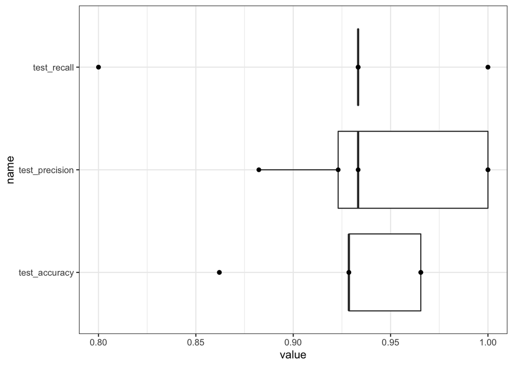

1. What do you expect the accuracy, precision, and recall to be on the test set, which we haven’t seen yet?

Now we construct the model’s predictions on the test set and store them in a variable called `y_test_pred`.

1. How many predictions are stored in `y_test_pred`?
2. Evaluate the model’s *accuracy*, *precision*, and *recall* on the test set.

```
## 0.9375
```

```
## 0.8888888888888888
```

```
## 1.0
```